# Predicting U.S. County COVID-19 Vaccination Rates

Natalie Walker and Eliana Squire

## Overview:

The COVID-19 vaccine offers the best protection against severe illness and prevention of future outbreaks, however the efficacy depends on a widespread uptake of the vaccine. Currently, the national vaccination rate approaches the ‘guide’ for herd immunity, but 45.8% of the population has yet to be fully vaccinated. Beyond the interests in public health, individuals resistant to the idea of getting the vaccine could benefit from policies that encourage its uptake. Utilizing a predictive machine learning model, we uncover which factors appear to influence vaccine uptake the most by predicting vaccination rates by county. Understanding the sociological background of those unwilling to obtain the vaccine can aid policymakers in designing incentive programs for those groups, as well as offer information for future pandemics.

## Methods:

# **Setting up the data**

## **Setting up: Vaccination Data**

```r
# Load CDC Covid-19 Vaccination Data for US counties over the course of the pandemic
# This data is updated weekly and the file includes all past entries.
vaccine = read_csv("county-vaccination.csv", show_col_types = FALSE)

# Rename variables for ease
vaccine %<>%
  rename(
    "County"="Recip_County",
    "State"="Recip_State" ,
    "Population"="Census2019" ,
    "Vax12Plus"="Series_Complete_12PlusPop_Pct",
    "Population18"="Census2019_18PlusPop",
    "Population65"="Census2019_65PlusPop"
    )

# Subset data to isolate one set of observations - 1/1/22
vaccine = subset(vaccine, Date == '1/1/22')

# Removing counties with missing FIPS (essential for identification)
vaccine = subset(vaccine, FIPS != "UNK")

# Remove rows with missing vaccine data
vaccine = subset(vaccine, Vax12Plus != 0)

# Remove Guam, Puerto Rico, and Virgin Islands
vaccine = subset(vaccine, State != c("GU", "PR", "VI"))

# Pad FIPS codes with 4 digits to have 0 on left (like it should)
vaccine$FIPS = str_pad(vaccine$FIPS, width = 5, side = "left", pad = "0")

# Create a dummy variable for Metro area
# There is only 1 missing value for Metro.
# Since the NA is a county that is in a metro area, the missing value will be getting 1
vaccine %<>% mutate(Metro =
                    ifelse(Metro_status == 'Metro', 1,
                    ifelse(Metro_status == 'Non-metro', 0, 1)))

# Create a variable for the percent of population under 18
# by finding the percent of the population over 18 and taking the difference
vaccine %<>% mutate(PopUnder18 = (100-((Population18/Population)*100)))
# Rounding to 2 digits
vaccine$PopUnder18 = round(vaccine$PopUnder18, digit = 2)

# Create a variable for the percent of population over 65 (a high risk group)
vaccine %<>% mutate(Pop65Plus = ((Population65/Population)*100))
# Rounding to 2 digits
vaccine$Pop65Plus = round(vaccine$Pop65Plus, digit = 2)

# Create a variable for the percent of population between 18 and 65
vaccine %<>% mutate(Pop18to65 = (100-PopUnder18-Pop65Plus))
# Rounding to 2 digits
vaccine$Pop18to65 = round(vaccine$Pop18to65, digit = 2)

# Subset data with only relevant variables
vaccine = subset(vaccine,
                 select=c("FIPS", "County", "State", "Vax12Plus", "Metro",
                          "Population", "Pop18to65", "Pop65Plus", "PopUnder18"))
```

## **Setting up: Education Data**

```r
# Load education dataset from the USDA Economic Research Service
education = read_csv("Education.csv", show_col_types = FALSE)

# Pad FIPS codes
education$FIPS = str_pad(education$FIPS, width = 5, side = "left", pad = "0")

# Remove county as it is formatted differently
education = select(education, -c(County))

#M Merge the vaccine data and the education data by FIPS code and State
df = merge(vaccine, education, by = c("FIPS", "State"))
```

## **Setting up: Work From Home Data**

```r
# Load work from home dataset from the USDA Economic Research Service
WFH = read_csv("WFH.csv", show_col_types = FALSE)

# Pad FIPS. Did not have a FIPS section - I created this in Excel.
WFH$FIPS = str_pad(WFH$FIPS, width = 5, side = "left", pad = "0")

# Round population density
WFH$PopDensity = round(WFH$PopDensity, digit = 2)

# Subset with relevant variables
WFH = subset(WFH, select = c("FIPS", "PopDensity", "WFH"))

# Merge to df by FIPS
df = merge(df, WFH, by = c("FIPS"))

# Create percent of population that works from home
df %<>% mutate(WFH=(WFH/Pop18to65)*100)
```

## **Setting up: Poverty Data**

```r
# Load poverty dataset from the USDA Economic Research Service
poverty = read_csv("Poverty.csv", show_col_types = FALSE)

# Remove state and county, as those variables are formatted differently
poverty = select(poverty, -c(STATEFP, COUNTYFP))

# Pad FIPS
poverty$FIPS = str_pad(poverty$FIPS, width = 5, side = "left", pad = "0")

# Merge to df by FIPS
df = merge(df, poverty, by = c("FIPS"))
```

## **Setting up: Presidential Election Data**

### **Presidential Election Data - 2012**

```r
# Load the dataset - includes elections from 2000-2020 and information on each party.
# We are interested in elections within the past 10 years.
electionsall = read_csv("countypres_2000-2020.csv", show_col_types = FALSE)

# Remove unnecessary variables
electionsall = select(electionsall, -c(state, county_name, office, version, candidate, mode))

# Rename variables for ease
electionsall %<>% rename("State" = "state_po",
                         "FIPS" = "county_fips")

# Pad FIPS
electionsall$FIPS = str_pad(electionsall$FIPS, width = 5, side = "left", pad = "0")

# Subset 2012 election
election2012 = subset(electionsall, year == '2012')

# Subset Democrat party for 2012 election
dem2012 = subset(election2012, party == 'DEMOCRAT')
# Create a variable for the percent of total votes cast for Democrats in the 2012 election
dem2012 %<>% mutate(dem2012pct = candidatevotes/totalvotes*100)
# Round
dem2012$dem2012pct = round(dem2012$dem2012pct, digit = 2)
# Subset to remove irrelevant variables
dem2012 = select(dem2012, -c(year, totalvotes, candidatevotes, party))
# Merge to df by FIPS and State
df = merge(df, dem2012, by = c("FIPS", "State"))

# Subset Republican party for 2012 election
rep2012 = subset(election2012, party == 'REPUBLICAN')
# Create a variable for the percent of total votes cast for Republicans in the 2012 election
rep2012 %<>% mutate(rep2012pct = candidatevotes/totalvotes*100)
# Round
rep2012$rep2012pct = round(rep2012$rep2012pct, digit = 2)
# Subset to remove irrelevant variables
rep2012 = select(rep2012, -c(year, totalvotes, candidatevotes, party))
# Merge to df by FIPS and State
df = merge(df, rep2012, by = c("FIPS", "State"))

# Create a dummy variable for Democrat majority in 2012 election
df %<>% mutate(dem2012 = ifelse(dem2012pct > rep2012pct, 1, 0))
```

### **Presidential Election Data - 2016**

```r
# Subset 2016 elections
election2016 = subset(electionsall, year == '2016')

# Subset Democrat party for 2016 election
dem2016 = subset(election2016, party == 'DEMOCRAT')

# Create a variable for the percent of total votes cast for Democrats in the 2016 election
dem2016 = dem2016 %>% mutate(dem2016pct=candidatevotes/totalvotes*100)
# Round
dem2016$dem2016pct = round(dem2016$dem2016pct, digit = 2)

# Subset to remove irrelevant variables
dem2016 = select(dem2016, -c(year, totalvotes, candidatevotes, party))

# Merge to df by FIPS and State
df = merge(df, dem2016, by=c("FIPS", "State"))


# Subset Republican party for 2016 election
rep2016 = subset(election2016, party == 'REPUBLICAN')

# Create a variable for the percent of total votes cast for Republicans in the 2012 election
rep2016 %<>% mutate(rep2016pct=candidatevotes/totalvotes*100)
# Round
rep2016$rep2016pct = round(rep2016$rep2016pct,digit=2)

# Subset to remove irrelevant variables
rep2016 = select(rep2016, -c(year, totalvotes, candidatevotes, party))

# Merge to df by FIPS and State
df = merge(df, rep2016, by=c("FIPS", "State"))

# Create a dummy variable for Democrat majority in 2016 election
df %<>% mutate(dem2016 = ifelse(dem2016pct > rep2016pct, 1,0))
```

### **Presidential Election Data - 2020**

```r
# Subset 2020 elections
election2020 = subset(electionsall, year == '2020')

# Subset Democrat party for 2020 election
dem2020 = subset(election2020, party == 'DEMOCRAT')

# Within the 2020 elections, there are several cases of counties that have multiple
# lines for their results, which is an issue.
# Fix formatting
dem2020 %<>%
  group_by(FIPS) %<>%
  # Combine the candidate votes for counties with multiple entries, but keep
  # total votes the same
  dplyr::summarise(candidatevotes = sum(candidatevotes),
                   totalvotes = totalvotes,
                   State = State) %<>%
  # Now, we have the accurate candidatevotes value
  as.data.frame()

# Remove duplicated FIPS
dem2020 = dem2020[!duplicated(dem2020$FIPS), ]

# Create a variable for the percent of total votes cast for Democrats in the 2020 election
dem2020 %<>% mutate(dem2020pct = candidatevotes/totalvotes*100)
# Round
dem2020$dem2020pct = round(dem2020$dem2020pct,digit=2)

# Remove irrelevant variables
dem2020 = select(dem2020, -c(totalvotes, candidatevotes))

# Merge to df by FIPS and State
df = merge(df, dem2020, by = c("FIPS", "State"))


# Subset Republican party for 2020 election
rep2020 = subset(election2020, party == 'REPUBLICAN')

# Fix formatting
rep2020 %<>%
  group_by(FIPS) %<>%
  # Combine the candidate votes for counties with multiple entries, but keep
  # total votes the same
  dplyr::summarise(candidatevotes = sum(candidatevotes),
                   totalvotes = totalvotes,
                   State = State) %<>%
  # Now, we have the accurate candidatevotes value
  as.data.frame()

# Remove duplicated FIPS
rep2020 = rep2020[!duplicated(rep2020$FIPS), ]

# Create a variable for the percent of total votes cast for Republicans in the 2020 election
rep2020 %<>% mutate(rep2020pct=candidatevotes/totalvotes*100)
# Round
rep2020$rep2020pct = round(rep2020$rep2020pct,digit=2)

# Remove irrelevant variables
rep2020 = select(rep2020, -c(totalvotes, candidatevotes))

# Merge to DF by FIPS and State
df = merge(df, rep2020, by=c("FIPS", "State"))
# Round
df%<>% mutate(dem2020 = ifelse(dem2020pct > rep2020pct, 1,0))
```

## **Presidential Election Data - Voting Patterns Over Time**

```r
# Create variables for voting patterns
#Previous Democrat voting
df %<>% mutate(pastvoting_dem = (dem2012+dem2016+dem2020))

# Average percent of votes Republican in past 3 presidential elections
df %<>% mutate(avgpct_rep = ((rep2012pct+rep2016pct+rep2020pct)/3))

# Average percent of votes Democrat in past 3 presidential elections
df %<>% mutate(avgpct_dem = ((dem2012pct+dem2016pct+dem2020pct)/3))

# Round
df$pastvoting_dem = round(df$pastvoting_dem,digit = 2)
df$avgpct_rep = round(df$avgpct_rep, digit = 2)
df$avgpct_dem = round(df$avgpct_dem, digit = 2)

# Remove unnecessary variables
df = subset(df, select=-c(dem2012pct, dem2016pct,dem2020pct, rep2012pct,
                          rep2016pct, rep2020pct, Pop18to65))
# Filter
df %<>% filter(is.na(avgpct_dem) == FALSE)
#Rename df
covid = df
# Write new CSV so do not have to load code every time
# write.csv(df,"524Project.csv", row.names = FALSE)
```

# **Exploring Data**

## **Exploring Data: Map**

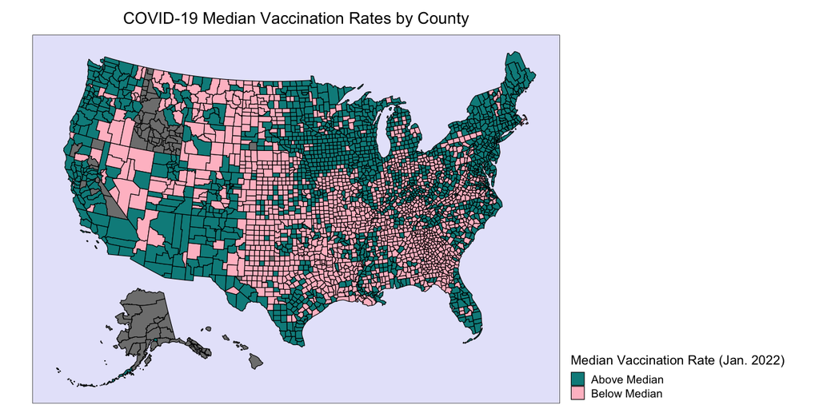

```r
# County Covid vaccination rates across the US
covid_map = covid %>% rename(fips = FIPS)

covid_map %<>%
  mutate(above_med = ifelse(Vax12Plus >= 54.3, "Above Median", "Below Median"))

# graph vaccination rates
plot_usmap(
  data = covid_map, values = "above_med") +
  scale_fill_manual(values = c("Above Median" = "dark cyan", "Below Median" = "pink"),
                    name = "Median Vaccination Rate (Jan. 2022)") +
  ggtitle("COVID-19 Median Vaccination Rates by County") +
  theme(legend.position = "right",
        legend.text = element_text(size=14),
        legend.title = element_text(size=16),
        panel.background = element_rect(fill="lavender"),
        plot.title = element_text(hjust = 0.5,
                                  size = 20,
                                  margin = margin(t = 10, b = 10)))
```

## **Exploring Data: Correlation Heat Map**

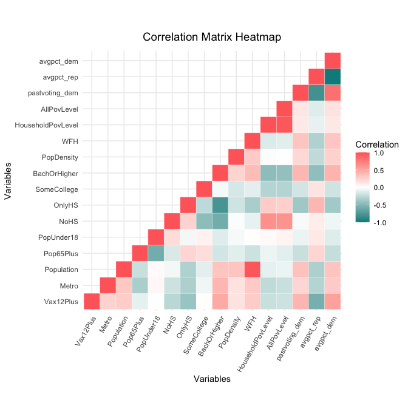

```r
# Correlation heat map
# Create normal correlation matrix
covid1 = covid %>% subset(select = -c(1,2,3,17,18, 19))
# Round
cormat = round(cor(covid1),2)

# Melt package
p_load(reshape2)
  get_upper_tri <- function(cormat){
    cormat[lower.tri(cormat)]<- NA
    return(cormat)
  }
  upper_tri <- get_upper_tri(cormat)
  melted_cormat <- melt(upper_tri, na.rm = TRUE)

# Plot heatmap
ggplot(data = melted_cormat,
       aes(Var2, Var1, fill = value)) +
       coord_fixed() +
       geom_tile(color = "white") +
       scale_fill_gradient2(low = "dark cyan", high = "indianred1", mid = "white",
                            midpoint = 0, limit = c(-1,1), space = "Lab",
                            name="Correlation") +
       theme_minimal() +
       labs(x ="Variables", y ="Variables",
            title = "Correlation Matrix Heatmap") +
       theme(axis.text.x = element_text(angle = 60, vjust = 1,  hjust = 1),
             plot.title = element_text(hjust = 0.5,
                                       size = 14,
                                       margin = margin(t = 10, b = 10)))
```

# **Working with the data**

## **Split & Recipe**

```r
# Set seed
set.seed(1)

# Remove county and state columns
covid %<>% subset(select = -c(2,3))

# Make Split
covid_split = covid %>% initial_split(prop = 0.8, strata = Vax12Plus)

# Separate training and testing data
covid_train = covid_split %>% training()
covid_test = covid_split %>% testing()

# Define the recipe:
covid_recipe =
  recipe(Vax12Plus ~ .,data = covid_train) %>%
  # Normalize for numeric predictors
  step_normalize(all_predictors() & all_numeric()) %>%
  # KNN imputation for categorical predictors
  # unnecessary
  step_impute_knn(all_predictors() & all_nominal(), neighbors = 5) %>%
  # Create dummies for categorical variables
  step_dummy(all_predictors() & all_nominal()) %>%
  update_role(FIPS, new_role = "id variable")

# Define the 5-fold split
covid_cv = covid_train %>% vfold_cv(v = 5)
```